# Chapter 11 Notes

**Chapter 11 Notes - Properties of Solutions**

**Mass percent**: mass of solute / mass of solution * 100%

**Molality**: moles of solute / kilograms of solvent

**Normality**: the number of “equivalents” per liter of solution (definition of “equivalent” depends on the reaction taking place; for acid-base reactions, it’s the mass of acid or base that can accept one mole of protons).

**Enthalpy of solution** (ΔH<sub>soln</sub>): the enthalpy change associated with the formation of a solution. Involves 1. Separating the solute into its individual components, 2. Overcoming the solvent’s IMFs to make room for the solute, and 3. Allowing the solute and solvent to form the solution.

**Enthalpy of hydration** (ΔH<sub>hyd</sub>): represents the enthalpy change associated with the dispersal of a gaseous solute in water; step 2 and 3 from above. Thus

ΔH<sub>soln</sub> = ΔH<sub>hyd</sub> + ΔH<sub>1</sub>

**Henry’s Law**: C = kP, where C represents the concentration of dissolved gas, k is a constant characteristic of a particular solution, and P represents the partial pressure of the gaseous solute above the solution. *The amount of gas dissolved in a solution is directly proportional to the pressure of the gas above the solution.*

The dissolving of a solid occurs *more rapidly* at higher temperatures, but the amount that can be dissolved may increase *or decrease* with increasing temperature.

**Raoult’s Law**: P<sub>soln</sub> = X<sub>solvent</sub> * P<sup>0</sup><sub>solvent</sub> , where P<sub>soln</sub> is the observed vapor pressure of the solution, X<sub>solvent</sub> is the mole fraction of the solvent, and P<sup>0</sup><sub>solvent</sub> is the vapor pressure of the pure solvent.

**Ideal solution**: one that perfectly obeys Raoult’s law, as the solute and solvent are very much alike causing the solute to simply dilute the solvent. However if the solvent has a special affinity for the solute (such as H-bonding), the tendency of the solvent molecules to escape will be lowered more than expected, lowering the vapor pressure predicted by Raoult’s law.

*(image on next page)*

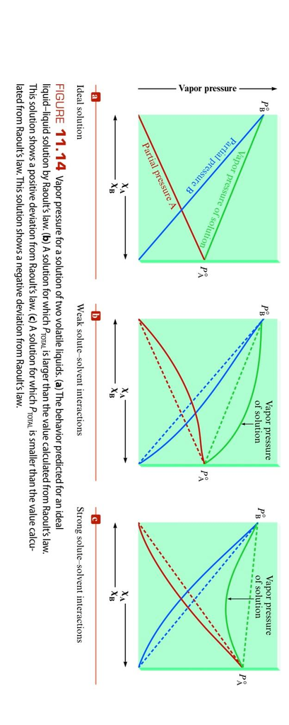

**Colligative properties**: a group of properties that depend only on the number, not the identity, of the solute particles in an ideal solution. Includes Freezing-point depression, boiling-point elevation, and osmotic pressure.

The change in boiling point due to boiling-point elevation can be represented by

ΔT = K<sub>b</sub>m<sub>solute</sub> , where K<sub>b</sub> is a constant that is characteristic of the solvent called the molal boiling-point elevation constant, and m<sub>solute</sub> is the *molality* of the solute in the solution.

Exact same goes for freezing-point depression.

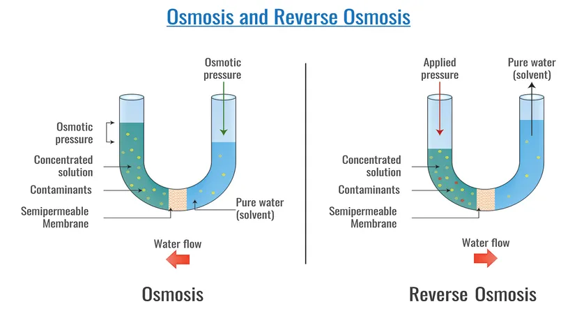

Reverse osmosis is used in the desalination of seawater, where the semipermeable membrane acts to filter out solute particles (dissolved salts).

**Isotonic solutions**: solutions that have identical osmotic pressures.

The relationship between the moles of solute dissolved and the moles of particles in solution is usually expressed using the **van’t Hoff factor**, i:

i = moles of particles in solution / moles of solute dissolved

**Tyndall effect**: the scattering of light by particles, often used to test if a solution is a true solution or a suspension (eg. some tiny mud particles remain suspended).

**Colloidal dispersion** or **Colloid**: a suspension of tiny particles in some medium.